# Sex-stratified SDQ trajectories in GUS

## Descriptives tables by sex

**Descriptives: Males**

**Group**: Sex = M

| **Variable** | **Stats / Values** | **Freqs (% of Valid)** | **Graph** |
| --- | --- | --- | --- |
| MeFaff04 [factor] | 1. Not_at_all 2. A_lot 3. A_fair_amount 4. A_little | 619 ( 57.3% ) 24 ( 2.2% ) 95 ( 8.8% ) 342 ( 31.7% ) |  |
| MatEdu [factor] | 1. No qualification 2. Other 3. GCSEs 4. A levels 5. HNC, HND or equivalent 6. Degree | 39 ( 3.6% ) 3 ( 0.3% ) 220 ( 20.4% ) 229 ( 21.2% ) 150 ( 13.9% ) 438 ( 40.6% ) |  |
| EqvIncome [factor] | 1. Bottom Quintile ( 2. 2nd Quintile (>=B#12,217 3. 3rd Quintile (>=B#19,643 4. 4th Quintile (>=B#29,126 5. Top Quintile (>=B#37,857) | 152 ( 14.1% ) 230 ( 21.3% ) 204 ( 18.9% ) 285 ( 26.4% ) 209 ( 19.4% ) |  |
| ALeSNim2 [factor] | 1. 5 2. 1 3. 2 4. 3 5. 4 | 128 ( 11.9% ) 281 ( 26.0% ) 268 ( 24.8% ) 217 ( 20.1% ) 186 ( 17.2% ) |  |
| PtnrEdu [factor] | 1. No qualification 2. Other 3. GCSEs 4. A levels 5. HNC, HND or equivalent 6. Degree | 48 ( 5.2% ) 13 ( 1.4% ) 238 ( 25.9% ) 145 ( 15.8% ) 109 ( 11.9% ) 365 ( 39.8% ) |  |
| MatEmploy [factor] | 1. Full time 2. Part time 3. Not working | 204 ( 18.9% ) 578 ( 53.6% ) 296 ( 27.5% ) |  |
| MatEthnicity [factor] | 1. White 2. Other ethnic background | 1050 ( 97.5% ) 27 ( 2.5% ) |  |
| DeSf12mn [numeric] | Mean (sd) : 50.612 (8.837) min ≤ med ≤ max: 9.472 ≤ 53.267 ≤ 66.251 IQR (CV) : 7.101 (0.175) | 513 distinct values |  |

Generated by summarytools 1.0.1 ([R](https://www.r-project.org/) version 4.4.1)  
2024-11-19

**Descriptives: Females**

**Group**: Sex = F

| **Variable** | **Stats / Values** | **Freqs (% of Valid)** | **Graph** |
| --- | --- | --- | --- |
| MeFaff04 [factor] | 1. Not_at_all 2. A_lot 3. A_fair_amount 4. A_little | 623 ( 59.6% ) 28 ( 2.7% ) 77 ( 7.4% ) 317 ( 30.3% ) |  |
| MatEdu [factor] | 1. No qualification 2. Other 3. GCSEs 4. A levels 5. HNC, HND or equivalent 6. Degree | 44 ( 4.2% ) 4 ( 0.4% ) 203 ( 19.5% ) 215 ( 20.6% ) 167 ( 16.0% ) 410 ( 39.3% ) |  |
| EqvIncome [factor] | 1. Bottom Quintile ( 2. 2nd Quintile (>=B#12,217 3. 3rd Quintile (>=B#19,643 4. 4th Quintile (>=B#29,126 5. Top Quintile (>=B#37,857) | 150 ( 14.4% ) 227 ( 21.7% ) 200 ( 19.1% ) 268 ( 25.6% ) 200 ( 19.1% ) |  |
| ALeSNim2 [factor] | 1. 5 2. 1 3. 2 4. 3 5. 4 | 142 ( 13.6% ) 262 ( 25.1% ) 248 ( 23.7% ) 225 ( 21.5% ) 168 ( 16.1% ) |  |
| PtnrEdu [factor] | 1. No qualification 2. Other 3. GCSEs 4. A levels 5. HNC, HND or equivalent 6. Degree | 60 ( 6.6% ) 11 ( 1.2% ) 224 ( 24.8% ) 174 ( 19.2% ) 127 ( 14.0% ) 308 ( 34.1% ) |  |
| MatEmploy [factor] | 1. Full time 2. Part time 3. Not working | 202 ( 19.3% ) 595 ( 57.0% ) 247 ( 23.7% ) |  |
| MatEthnicity [factor] | 1. White 2. Other ethnic background | 1021 ( 97.8% ) 23 ( 2.2% ) |  |
| DeSf12mn [numeric] | Mean (sd) : 51.115 (8.674) min ≤ med ≤ max: 5.891 ≤ 53.719 ≤ 68.558 IQR (CV) : 7.453 (0.17) | 517 distinct values |  |

Generated by summarytools 1.0.1 ([R](https://www.r-project.org/) version 4.4.1)  
2024-11-19

## Group differences in categorical variables

| Var | X | df | p |
| --- | --- | --- | --- |
| MeFaff04 | 2.5567858 | 3 | 0.4651160 |
| MeFaff3lvl | 1.2258250 | 2 | 0.5417707 |
| Food | 0.9923215 | 1 | 0.3191757 |
| DeMedu03 | 3.6860361 | 5 | 0.5954434 |
| DeEqv5 | 0.3705459 | 4 | 0.9848166 |
| SIMD | 3.6589339 | 4 | 0.4541269 |

# Age-only trajectories split by sex

## Conduct problems

| sweep | Age | t | df | CI_low | CI_high | p | meanM | meanF |
| --- | --- | --- | --- | --- | --- | --- | --- | --- |
| De | 4.84 | 2.556 | 2105 | 0.03 | 0.26 | 0.011 | 1.68 | 1.53 |
| Df | 5.85 | 4.567 | 2108 | 0.16 | 0.39 | 0.000 | 1.59 | 1.32 |
| Dg | 7.86 | 4.592 | 2106 | 0.16 | 0.40 | 0.000 | 1.49 | 1.22 |
| Dh | 10.17 | 2.607 | 2103 | 0.04 | 0.27 | 0.009 | 1.23 | 1.07 |
| Di | 12.55 | 2.129 | 2066 | 0.01 | 0.26 | 0.033 | 1.23 | 1.10 |
| Dj | 14.61 | 0.723 | 2029 | -0.08 | 0.17 | 0.470 | 1.09 | 1.04 |

Original data, split by sex.

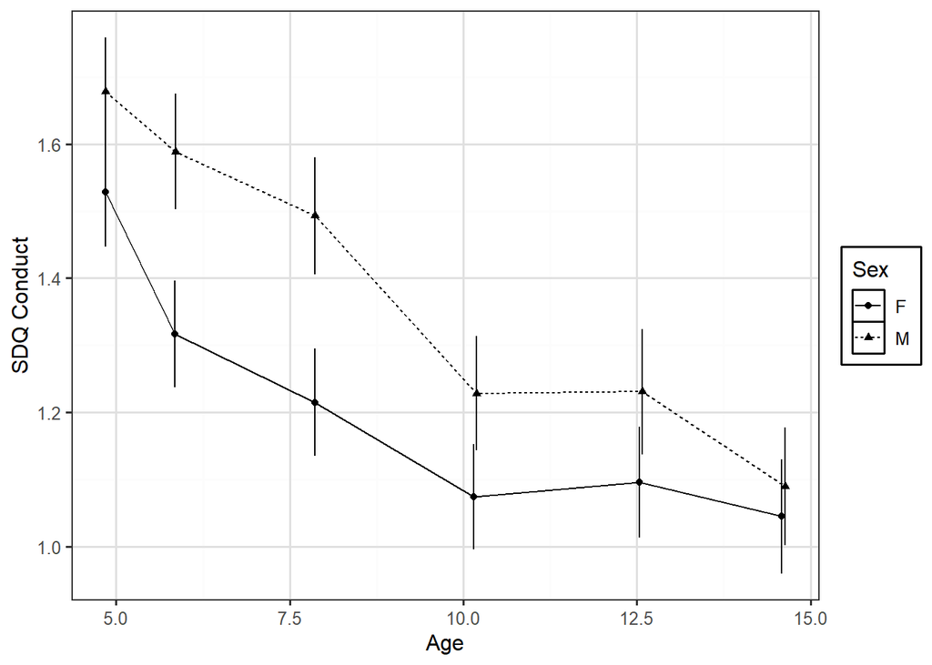

[1] “No singular fit” [1] “No convergence issues”

| REML |
| --- |
| 40653 |

|  | Dsdco1 |  |  |
| --- | --- | --- | --- |
| Predictors | Estimates | CI | p |
| (Intercept) | 1.37 | 1.30 – 1.45 | **<0.001** |
| age cent | -0.06 | -0.07 – -0.05 | **<0.001** |
| Sex [F] | -0.22 | -0.32 – -0.12 | **<0.001** |
| age cent^2 | 0.00 | 0.00 – 0.01 | **0.026** |
| age cent × Sex [F] | 0.01 | -0.00 – 0.03 | 0.054 |
| Sex [F] × age cent^2 | 0.00 | 0.00 – 0.01 | **0.047** |
| Random Effects |  |  |  |
| σ<sup>2</sup> | 0.81 |  |  |
| τ<sub>00</sub> <sub>Idnumber</sub> | 1.05 |  |  |
| τ<sub>11</sub> <sub>Idnumber.age.cent</sub> | 0.01 |  |  |
| ρ<sub>01</sub> <sub>Idnumber</sub> | 0.13 |  |  |
| ICC | 0.60 |  |  |
| N <sub>Idnumber</sub> | 2125 |  |  |
| Observations | 12591 |  |  |
| Marginal R<sup>2</sup> / Conditional R<sup>2</sup> | 0.020 / 0.608 |  |  |

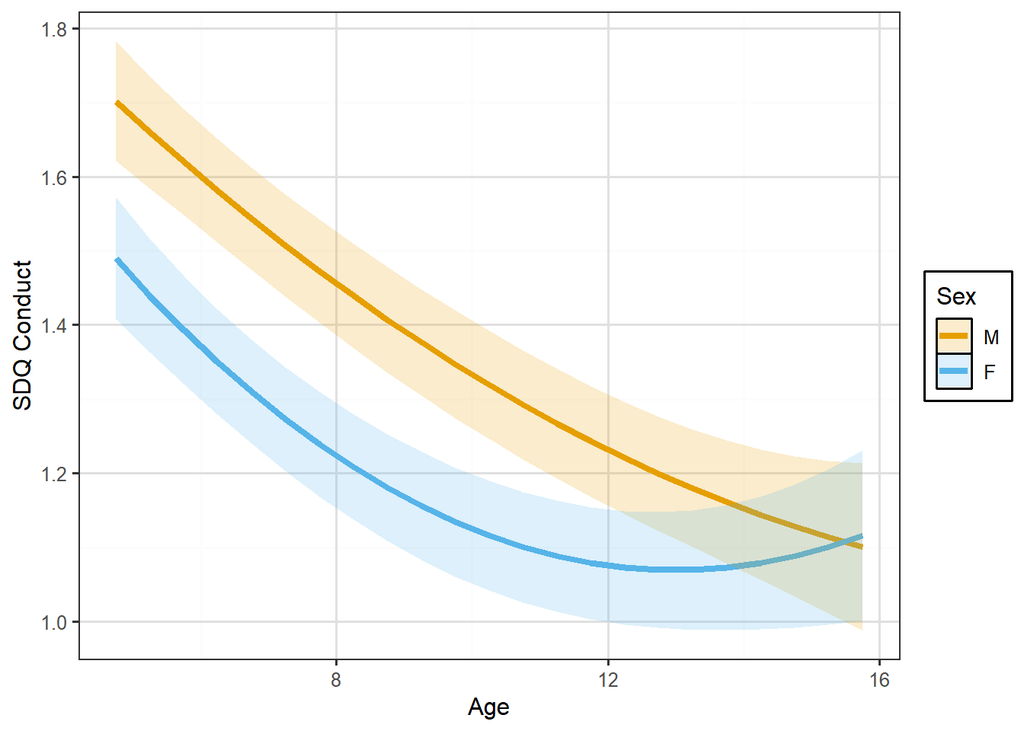

## Emotional problems

| sweep | Age | t | df | CI_low | CI_high | p | meanM | meanF |
| --- | --- | --- | --- | --- | --- | --- | --- | --- |
| De | 4.84 | -0.701 | 2108 | -0.16 | 0.08 | 0.484 | 1.16 | 1.20 |
| Df | 5.85 | -1.285 | 2114 | -0.21 | 0.04 | 0.199 | 1.16 | 1.25 |
| Dg | 7.86 | 0.220 | 2114 | -0.13 | 0.16 | 0.826 | 1.38 | 1.37 |
| Dh | 10.17 | -2.127 | 2100 | -0.33 | -0.01 | 0.034 | 1.50 | 1.66 |
| Di | 12.55 | -0.922 | 2090 | -0.26 | 0.09 | 0.357 | 1.75 | 1.83 |
| Dj | 14.61 | -6.170 | 1991 | -0.76 | -0.39 | 0.000 | 1.49 | 2.06 |

Original data, split by sex.

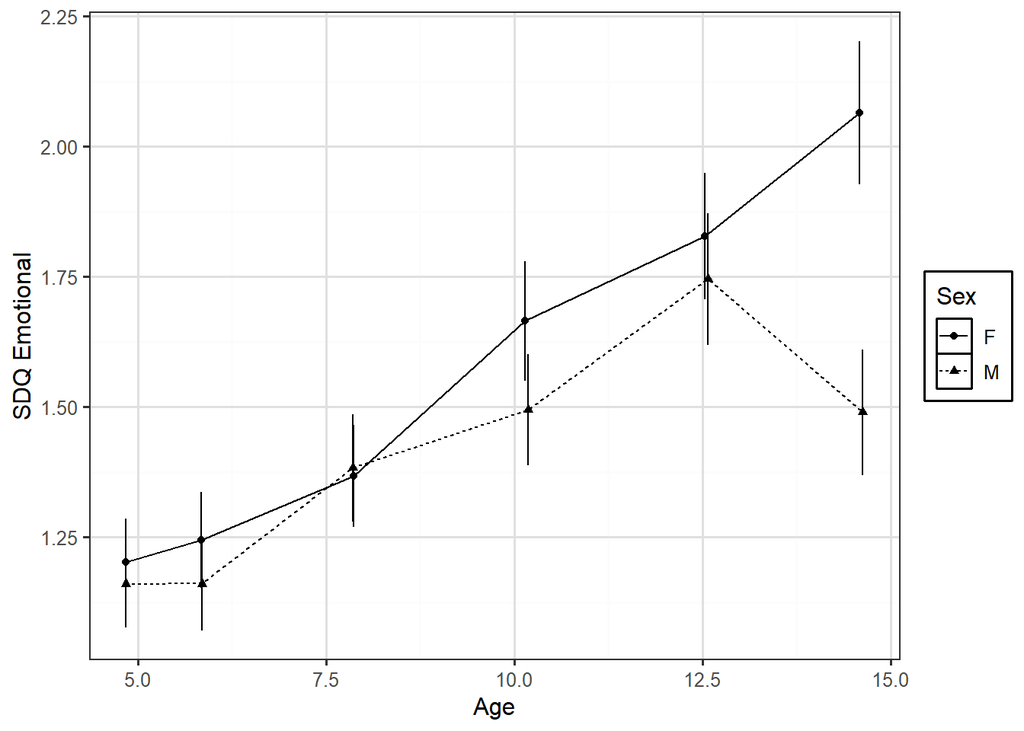

Cubic model with age*sex interactions.

[1] “No singular fit” [1] “No convergence issues”

| REML |
| --- |
| 46987 |

|  | Dsdem1 |  |  |
| --- | --- | --- | --- |
| Predictors | Estimates | CI | p |
| (Intercept) | 1.51 | 1.42 – 1.59 | **<0.001** |
| age cent | 0.11 | 0.08 – 0.14 | **<0.001** |
| Sex [F] | 0.04 | -0.09 – 0.17 | 0.550 |
| age cent^2 | -0.00 | -0.01 – -0.00 | **0.023** |
| age cent^3 | -0.00 | -0.00 – -0.00 | **<0.001** |
| age cent × Sex [F] | -0.01 | -0.05 – 0.02 | 0.509 |
| Sex [F] × age cent^2 | 0.01 | 0.00 – 0.01 | **0.009** |
| Sex [F] × age cent^3 | 0.00 | 0.00 – 0.00 | **0.004** |
| Random Effects |  |  |  |
| σ<sup>2</sup> | 1.37 |  |  |
| τ<sub>00</sub> <sub>Idnumber</sub> | 1.56 |  |  |
| τ<sub>11</sub> <sub>Idnumber.age.cent</sub> | 0.03 |  |  |
| ρ<sub>01</sub> <sub>Idnumber</sub> | 0.48 |  |  |
| ICC | 0.58 |  |  |
| N <sub>Idnumber</sub> | 2125 |  |  |
| Observations | 12591 |  |  |
| Marginal R<sup>2</sup> / Conditional R<sup>2</sup> | 0.024 / 0.592 |  |  |

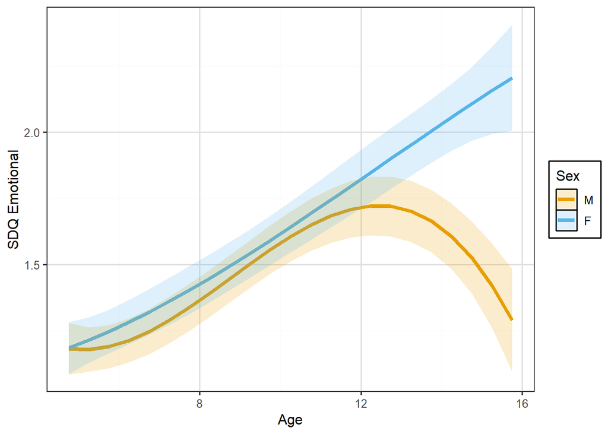

## Hyperactivity

| sweep | Age | t | df | CI_low | CI_high | p | meanM | meanF |
| --- | --- | --- | --- | --- | --- | --- | --- | --- |
| De | 4.84 | 6.46 | 2105 | 0.44 | 0.82 | 0 | 3.79 | 3.16 |
| Df | 5.85 | 6.59 | 2105 | 0.47 | 0.86 | 0 | 3.65 | 2.98 |
| Dg | 7.86 | 8.34 | 2114 | 0.67 | 1.08 | 0 | 3.71 | 2.83 |
| Dh | 10.17 | 8.12 | 2103 | 0.61 | 1.00 | 0 | 3.24 | 2.43 |
| Di | 12.55 | 8.89 | 2075 | 0.69 | 1.09 | 0 | 3.21 | 2.32 |
| Dj | 14.61 | 8.57 | 2008 | 0.66 | 1.06 | 0 | 2.97 | 2.10 |

Original data, split by sex.

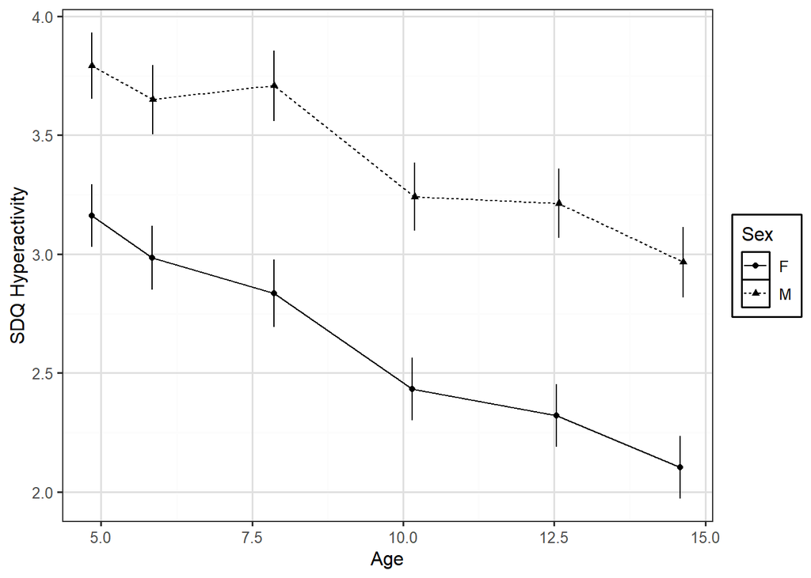

Quadratic model with age*sex interactions.

[1] “No singular fit” [1] “No convergence issues”

| REML |
| --- |
| 50382 |

|  | Dsdhy1 |  |  |
| --- | --- | --- | --- |
| Predictors | Estimates | CI | p |
| (Intercept) | 3.46 | 3.34 – 3.58 | **<0.001** |
| age cent | -0.08 | -0.09 – -0.06 | **<0.001** |
| Sex [F] | -0.85 | -1.02 – -0.67 | **<0.001** |
| age cent^2 | -0.00 | -0.00 – 0.00 | 0.884 |
| age cent × Sex [F] | -0.03 | -0.05 – -0.01 | **0.006** |
| Sex [F] × age cent^2 | 0.00 | -0.00 – 0.01 | 0.070 |
| Random Effects |  |  |  |
| σ<sup>2</sup> | 1.60 |  |  |
| τ<sub>00</sub> <sub>Idnumber</sub> | 3.45 |  |  |
| τ<sub>11</sub> <sub>Idnumber.age.cent</sub> | 0.03 |  |  |
| ρ<sub>01</sub> <sub>Idnumber</sub> | 0.03 |  |  |
| ICC | 0.71 |  |  |
| N <sub>Idnumber</sub> | 2125 |  |  |
| Observations | 12591 |  |  |
| Marginal R<sup>2</sup> / Conditional R<sup>2</sup> | 0.046 / 0.720 |  |  |

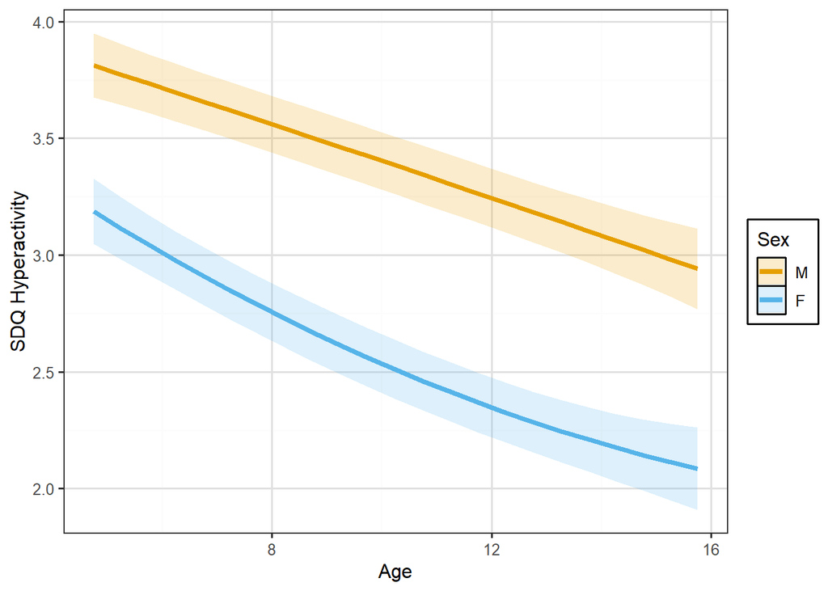

## Peer problems

| sweep | Age | t | df | CI_low | CI_high | p | meanM | meanF |
| --- | --- | --- | --- | --- | --- | --- | --- | --- |
| De | 4.84 | 2.67 | 2089 | 0.04 | 0.25 | 0.008 | 0.982 | 0.838 |
| Df | 5.85 | 2.88 | 2104 | 0.05 | 0.27 | 0.004 | 0.924 | 0.765 |
| Dg | 7.86 | 3.74 | 2067 | 0.11 | 0.35 | 0.000 | 1.119 | 0.887 |
| Dh | 10.17 | 3.68 | 2048 | 0.12 | 0.39 | 0.000 | 1.256 | 1.002 |
| Di | 12.55 | 4.46 | 2038 | 0.19 | 0.49 | 0.000 | 1.517 | 1.174 |
| Dj | 14.61 | 2.26 | 2014 | 0.02 | 0.33 | 0.024 | 1.545 | 1.368 |

Original data, split by sex.

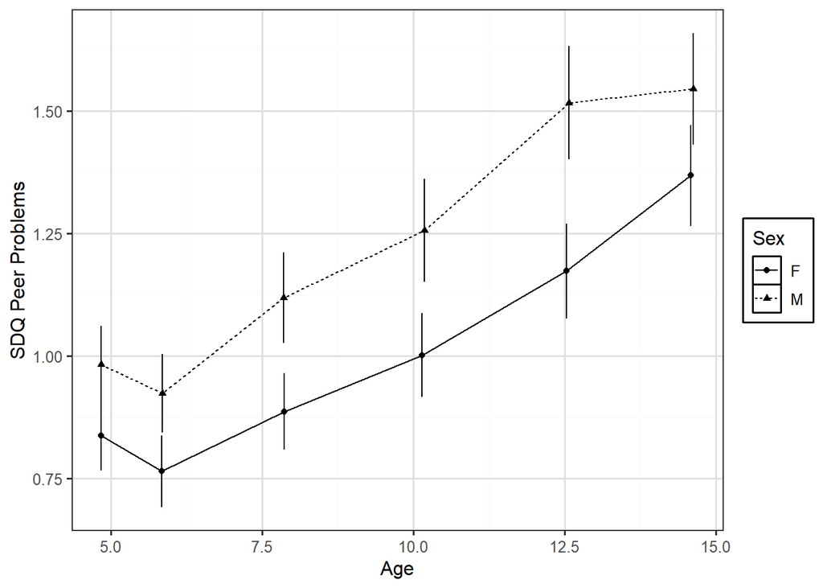

Cubic model with age*sex interactions.

[1] “No singular fit” [1] “No convergence issues”

| REML |
| --- |
| 42985 |

|  | Dsdpr1 |  |  |
| --- | --- | --- | --- |
| Predictors | Estimates | CI | p |
| (Intercept) | 1.26 | 1.18 – 1.34 | **<0.001** |
| age cent | 0.10 | 0.08 – 0.12 | **<0.001** |
| Sex [F] | -0.31 | -0.42 – -0.20 | **<0.001** |
| age cent^2 | 0.00 | -0.00 – 0.00 | 0.992 |
| age cent^3 | -0.00 | -0.00 – -0.00 | **0.005** |
| age cent × Sex [F] | -0.05 | -0.08 – -0.01 | **0.004** |
| Sex [F] × age cent^2 | 0.01 | 0.00 – 0.01 | **0.008** |
| Sex [F] × age cent^3 | 0.00 | 0.00 – 0.00 | **0.036** |
| Random Effects |  |  |  |
| σ<sup>2</sup> | 0.99 |  |  |
| τ<sub>00</sub> <sub>Idnumber</sub> | 1.19 |  |  |
| τ<sub>11</sub> <sub>Idnumber.age.cent</sub> | 0.02 |  |  |
| ρ<sub>01</sub> <sub>Idnumber</sub> | 0.51 |  |  |
| ICC | 0.59 |  |  |
| N <sub>Idnumber</sub> | 2125 |  |  |
| Observations | 12591 |  |  |
| Marginal R<sup>2</sup> / Conditional R<sup>2</sup> | 0.026 / 0.601 |  |  |

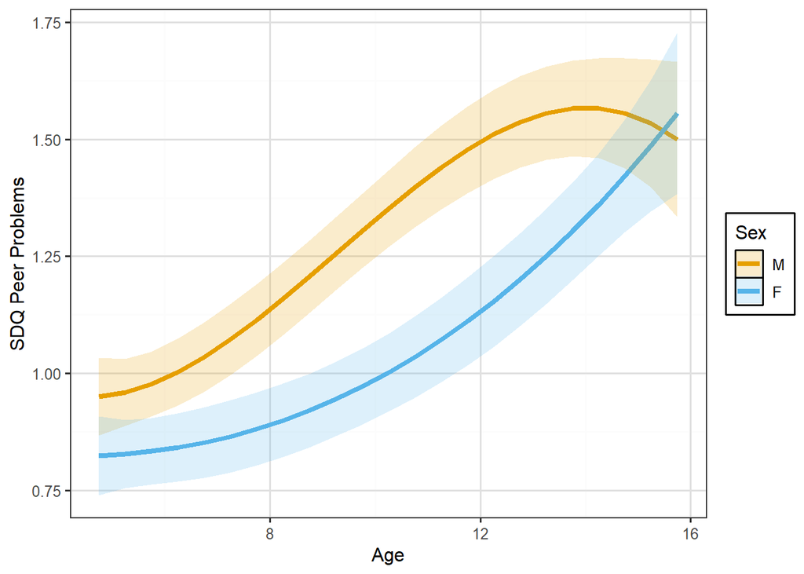

# 3-level FI trajectories by sex

## Male only

GUS SDQ scores by sweep, male only. Mean (SD)

| sweep | N | Age | Conduct | Emotional | Hyperactivity | Peer_Problem |
| --- | --- | --- | --- | --- | --- | --- |
| De | 1070 | 4.84 (0.04) | 1.68 (1.34) | 1.16 (1.4) | 3.79 (2.31) | 0.98 (1.32) |
| Df | 1075 | 5.85 (0.04) | 1.59 (1.44) | 1.16 (1.49) | 3.65 (2.44) | 0.92 (1.34) |
| Dg | 1077 | 7.86 (0.06) | 1.49 (1.47) | 1.38 (1.72) | 3.71 (2.49) | 1.12 (1.56) |
| Dh | 1073 | 10.19 (0.3) | 1.23 (1.43) | 1.49 (1.79) | 3.24 (2.41) | 1.26 (1.75) |
| Di | 1058 | 12.57 (0.31) | 1.23 (1.55) | 1.75 (2.1) | 3.21 (2.42) | 1.52 (1.92) |
| Dj | 1025 | 14.63 (0.38) | 1.09 (1.44) | 1.49 (1.97) | 2.97 (2.4) | 1.55 (1.86) |

### Conduct problems

[1] “No singular fit” [1] “No convergence issues”

| REML |
| --- |
| 20933 |

|  | Dsdco1 |  |  |
| --- | --- | --- | --- |
| Predictors | Estimates | CI | p |
| (Intercept) | 1.24 | 1.14 – 1.34 | **<0.001** |
| age cent | -0.06 | -0.07 – -0.04 | **<0.001** |
| MeFaff3lvl [A lot/fair amount] | 0.61 | 0.37 – 0.85 | **<0.001** |
| MeFaff3lvl [A little] | 0.20 | 0.03 – 0.36 | **0.018** |
| age cent^2 | 0.00 | -0.00 – 0.00 | 0.699 |
| age cent × MeFaff3lvl [A lot/fair amount] | 0.00 | -0.03 – 0.04 | 0.818 |
| age cent × MeFaff3lvl [A little] | -0.02 | -0.04 – 0.01 | 0.151 |
| MeFaff3lvl [A lot/fair amount] × age cent^2 | -0.00 | -0.01 – 0.00 | 0.323 |
| MeFaff3lvl [A little] × age cent^2 | 0.01 | 0.00 – 0.01 | **0.004** |
| Random Effects |  |  |  |
| σ<sup>2</sup> | 0.84 |  |  |
| τ<sub>00</sub> <sub>Idnumber</sub> | 1.11 |  |  |
| τ<sub>11</sub> <sub>Idnumber.age.cent</sub> | 0.02 |  |  |
| ρ<sub>01</sub> <sub>Idnumber</sub> | 0.16 |  |  |
| ICC | 0.61 |  |  |
| N <sub>Idnumber</sub> | 1080 |  |  |
| Observations | 6378 |  |  |
| Marginal R<sup>2</sup> / Conditional R<sup>2</sup> | 0.037 / 0.622 |  |  |

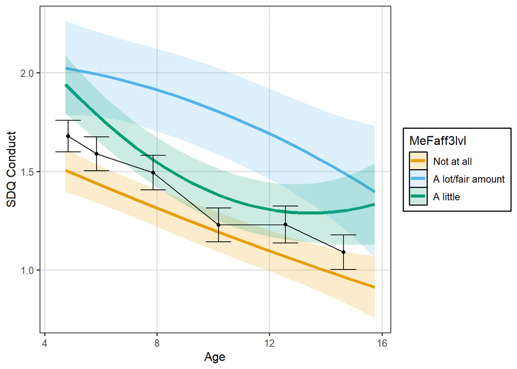

### Emotional problems

[1] “No singular fit” [1] “No convergence issues”

| REML |
| --- |
| 23930 |

|  | Dsdem1 |  |  |
| --- | --- | --- | --- |
| Predictors | Estimates | CI | p |
| (Intercept) | 1.29 | 1.17 – 1.41 | **<0.001** |
| age cent | 0.11 | 0.08 – 0.15 | **<0.001** |
| MeFaff3lvl [A lot/fair amount] | 0.80 | 0.52 – 1.09 | **<0.001** |
| MeFaff3lvl [A little] | 0.38 | 0.19 – 0.58 | **<0.001** |
| age cent^2 | -0.00 | -0.01 – 0.00 | 0.999 |
| age cent^3 | -0.00 | -0.01 – -0.00 | **<0.001** |
| age cent × MeFaff3lvl [A lot/fair amount] | -0.01 | -0.09 – 0.07 | 0.877 |
| age cent × MeFaff3lvl [A little] | -0.00 | -0.06 – 0.06 | 0.996 |
| MeFaff3lvl [A lot/fair amount] × age cent^2 | -0.01 | -0.02 – 0.00 | 0.098 |
| MeFaff3lvl [A little] × age cent^2 | -0.01 | -0.02 – -0.00 | **0.035** |
| MeFaff3lvl [A lot/fair amount] × age cent^3 | 0.00 | -0.00 – 0.00 | 0.683 |
| MeFaff3lvl [A little] × age cent^3 | 0.00 | -0.00 – 0.00 | 0.231 |
| Random Effects |  |  |  |
| σ<sup>2</sup> | 1.41 |  |  |
| τ<sub>00</sub> <sub>Idnumber</sub> | 1.53 |  |  |
| τ<sub>11</sub> <sub>Idnumber.age.cent</sub> | 0.03 |  |  |
| ρ<sub>01</sub> <sub>Idnumber</sub> | 0.45 |  |  |
| ICC | 0.57 |  |  |
| N <sub>Idnumber</sub> | 1080 |  |  |
| Observations | 6378 |  |  |
| Marginal R<sup>2</sup> / Conditional R<sup>2</sup> | 0.030 / 0.581 |  |  |

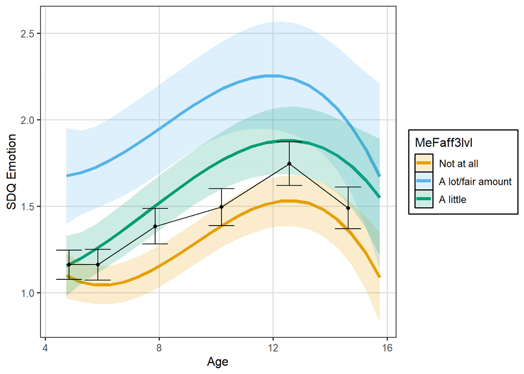

### Hyperactivity

[1] “No singular fit” [1] “No convergence issues”

| REML |
| --- |
| 26010 |

|  | Dsdhy1 |  |  |
| --- | --- | --- | --- |
| Predictors | Estimates | CI | p |
| (Intercept) | 3.23 | 3.07 – 3.39 | **<0.001** |
| age cent | -0.08 | -0.10 – -0.06 | **<0.001** |
| MeFaff3lvl [A lot/fair amount] | 1.05 | 0.66 – 1.44 | **<0.001** |
| MeFaff3lvl [A little] | 0.35 | 0.08 – 0.61 | **0.010** |
| age cent × MeFaff3lvl [A lot/fair amount] | -0.01 | -0.06 – 0.04 | 0.699 |
| age cent × MeFaff3lvl [A little] | 0.00 | -0.03 – 0.03 | 0.976 |
| Random Effects |  |  |  |
| σ<sup>2</sup> | 1.72 |  |  |
| τ<sub>00</sub> <sub>Idnumber</sub> | 3.69 |  |  |
| τ<sub>11</sub> <sub>Idnumber.age.cent</sub> | 0.04 |  |  |
| ρ<sub>01</sub> <sub>Idnumber</sub> | 0.07 |  |  |
| ICC | 0.71 |  |  |
| N <sub>Idnumber</sub> | 1080 |  |  |
| Observations | 6378 |  |  |
| Marginal R<sup>2</sup> / Conditional R<sup>2</sup> | 0.031 / 0.715 |  |  |

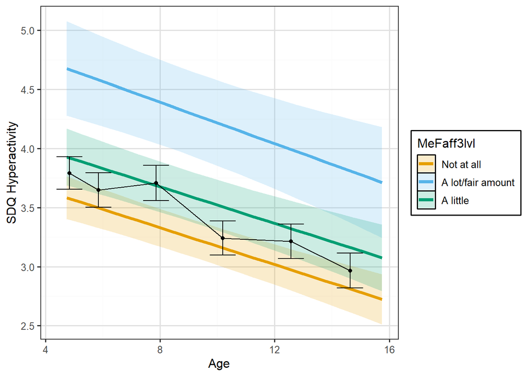

### Peer problems

[1] “No singular fit” [1] “No convergence issues”

| REML |
| --- |
| 22350 |

|  | Dsdpr1 |  |  |
| --- | --- | --- | --- |
| Predictors | Estimates | CI | p |
| (Intercept) | 1.07 | 0.96 – 1.18 | **<0.001** |
| age cent | 0.10 | 0.07 – 0.13 | **<0.001** |
| MeFaff3lvl [A lot/fair amount] | 0.72 | 0.44 – 0.99 | **<0.001** |
| MeFaff3lvl [A little] | 0.31 | 0.13 – 0.50 | **0.001** |
| age cent^2 | 0.00 | -0.00 – 0.01 | 0.327 |
| age cent^3 | -0.00 | -0.00 – -0.00 | **0.001** |
| age cent × MeFaff3lvl [A lot/fair amount] | 0.02 | -0.05 – 0.08 | 0.666 |
| age cent × MeFaff3lvl [A little] | -0.02 | -0.07 – 0.03 | 0.535 |
| MeFaff3lvl [A lot/fair amount] × age cent^2 | -0.01 | -0.02 – -0.00 | **0.014** |
| MeFaff3lvl [A little] × age cent^2 | -0.00 | -0.01 – 0.01 | 0.706 |
| MeFaff3lvl [A lot/fair amount] × age cent^3 | 0.00 | -0.00 – 0.00 | 0.459 |
| MeFaff3lvl [A little] × age cent^3 | 0.00 | 0.00 – 0.00 | **0.026** |
| Random Effects |  |  |  |
| σ<sup>2</sup> | 1.07 |  |  |
| τ<sub>00</sub> <sub>Idnumber</sub> | 1.44 |  |  |
| τ<sub>11</sub> <sub>Idnumber.age.cent</sub> | 0.02 |  |  |
| ρ<sub>01</sub> <sub>Idnumber</sub> | 0.56 |  |  |
| ICC | 0.61 |  |  |
| N <sub>Idnumber</sub> | 1080 |  |  |
| Observations | 6378 |  |  |
| Marginal R<sup>2</sup> / Conditional R<sup>2</sup> | 0.038 / 0.628 |  |  |

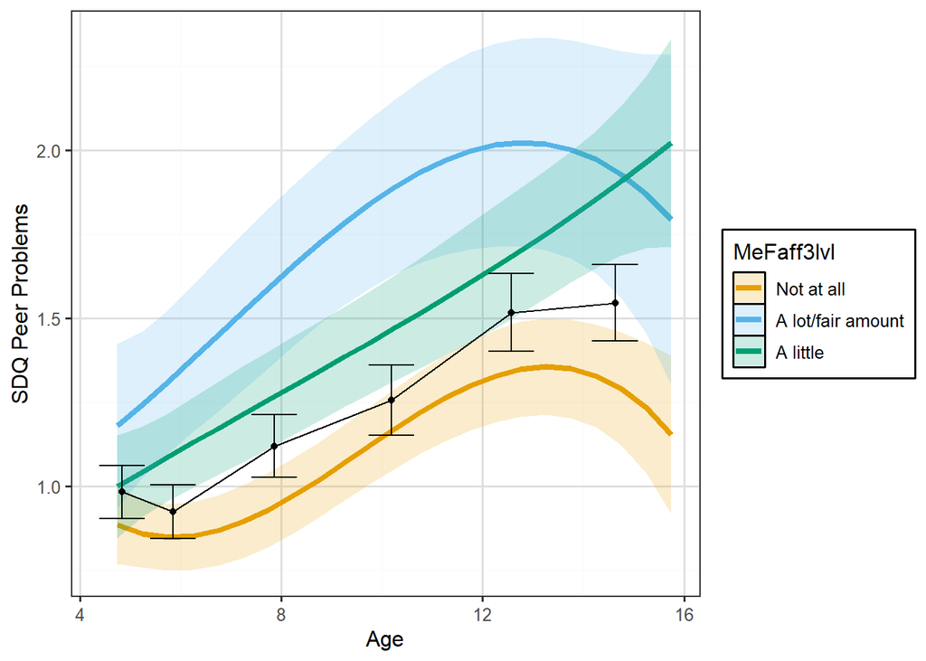

## Female only

GUS SDQ scores by sweep, female only. Mean (SD)

| sweep | N | Age | Conduct | Emotional | Hyperactivity | Peer_Problem |
| --- | --- | --- | --- | --- | --- | --- |
| De | 1040 | 4.84 (0.04) | 1.53 (1.35) | 1.2 (1.37) | 3.16 (2.16) | 0.84 (1.17) |
| Df | 1045 | 5.85 (0.04) | 1.32 (1.3) | 1.24 (1.52) | 2.98 (2.2) | 0.76 (1.2) |
| Dg | 1042 | 7.86 (0.06) | 1.21 (1.32) | 1.37 (1.61) | 2.83 (2.33) | 0.89 (1.29) |
| Dh | 1043 | 10.15 (0.29) | 1.07 (1.29) | 1.67 (1.89) | 2.43 (2.18) | 1 (1.42) |
| Di | 1036 | 12.53 (0.31) | 1.1 (1.35) | 1.83 (1.99) | 2.32 (2.16) | 1.17 (1.59) |
| Dj | 1007 | 14.59 (0.36) | 1.04 (1.37) | 2.06 (2.22) | 2.1 (2.12) | 1.37 (1.67) |

### Conduct problems

[1] “No singular fit” [1] “No convergence issues”

| REML |
| --- |
| 19681 |

|  | Dsdco1 |  |  |
| --- | --- | --- | --- |
| Predictors | Estimates | CI | p |
| (Intercept) | 1.09 | 1.00 – 1.18 | **<0.001** |
| age cent | -0.04 | -0.05 – -0.03 | **<0.001** |
| MeFaff3lvl [A lot/fair amount] | 0.53 | 0.30 – 0.76 | **<0.001** |
| MeFaff3lvl [A little] | 0.05 | -0.10 – 0.20 | 0.516 |
| age cent^2 | 0.00 | 0.00 – 0.01 | **0.005** |
| age cent × MeFaff3lvl [A lot/fair amount] | -0.01 | -0.04 – 0.02 | 0.635 |
| age cent × MeFaff3lvl [A little] | -0.01 | -0.03 – 0.01 | 0.443 |
| MeFaff3lvl [A lot/fair amount] × age cent^2 | 0.01 | 0.00 – 0.02 | **0.008** |
| MeFaff3lvl [A little] × age cent^2 | 0.00 | -0.00 – 0.01 | 0.761 |
| Random Effects |  |  |  |
| σ<sup>2</sup> | 0.78 |  |  |
| τ<sub>00</sub> <sub>Idnumber</sub> | 0.91 |  |  |
| τ<sub>11</sub> <sub>Idnumber.age.cent</sub> | 0.01 |  |  |
| ρ<sub>01</sub> <sub>Idnumber</sub> | 0.10 |  |  |
| ICC | 0.58 |  |  |
| N <sub>Idnumber</sub> | 1045 |  |  |
| Observations | 6213 |  |  |
| Marginal R<sup>2</sup> / Conditional R<sup>2</sup> | 0.032 / 0.589 |  |  |

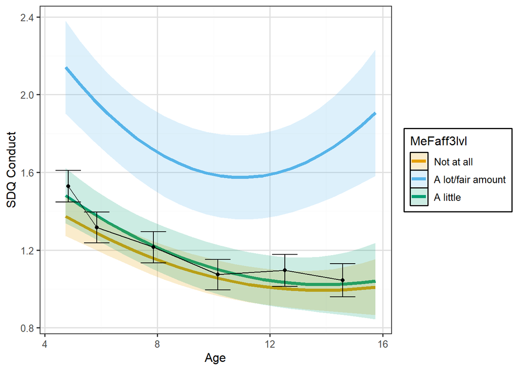

### Emotional problems

[1] “No singular fit” [1] “No convergence issues”

| REML |
| --- |
| 23030 |

|  | Dsdem1 |  |  |
| --- | --- | --- | --- |
| Predictors | Estimates | CI | p |
| (Intercept) | 1.43 | 1.33 – 1.53 | **<0.001** |
| age cent | 0.09 | 0.07 – 0.11 | **<0.001** |
| MeFaff3lvl [A lot/fair amount] | 0.72 | 0.45 – 0.99 | **<0.001** |
| MeFaff3lvl [A little] | 0.23 | 0.05 – 0.41 | **0.012** |
| age cent × MeFaff3lvl [A lot/fair amount] | 0.02 | -0.03 – 0.06 | 0.507 |
| age cent × MeFaff3lvl [A little] | -0.00 | -0.03 – 0.03 | 0.910 |
| Random Effects |  |  |  |
| σ<sup>2</sup> | 1.33 |  |  |
| τ<sub>00</sub> <sub>Idnumber</sub> | 1.49 |  |  |
| τ<sub>11</sub> <sub>Idnumber.age.cent</sub> | 0.03 |  |  |
| ρ<sub>01</sub> <sub>Idnumber</sub> | 0.53 |  |  |
| ICC | 0.58 |  |  |
| N <sub>Idnumber</sub> | 1045 |  |  |
| Observations | 6213 |  |  |
| Marginal R<sup>2</sup> / Conditional R<sup>2</sup> | 0.046 / 0.603 |  |  |

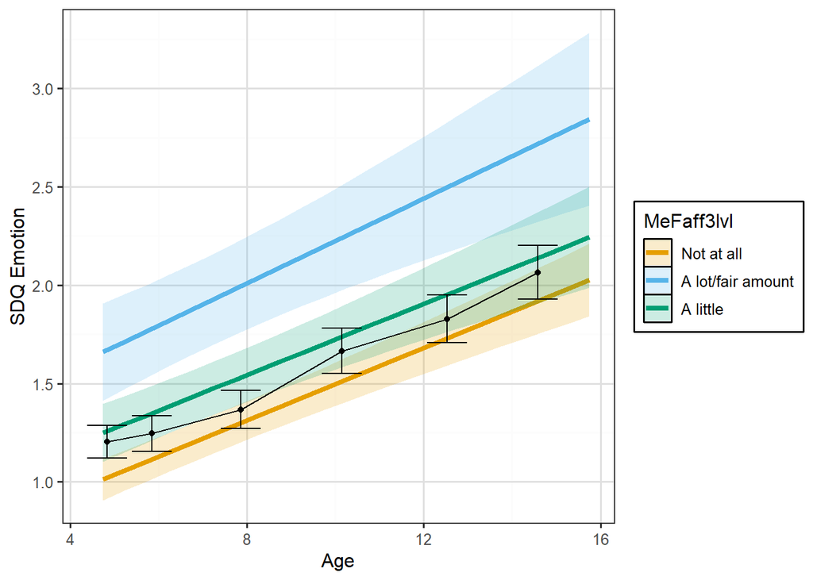

### Hyperactivity

[1] “No singular fit” [1] “No convergence issues”

| REML |
| --- |
| 24296 |

|  | Dsdhy1 |  |  |
| --- | --- | --- | --- |
| Predictors | Estimates | CI | p |
| (Intercept) | 2.49 | 2.33 – 2.64 | **<0.001** |
| age cent | -0.10 | -0.12 – -0.08 | **<0.001** |
| MeFaff3lvl [A lot/fair amount] | 0.66 | 0.27 – 1.06 | **0.001** |
| MeFaff3lvl [A little] | 0.21 | -0.06 – 0.47 | 0.125 |
| age cent^2 | 0.00 | -0.00 – 0.01 | 0.506 |
| age cent × MeFaff3lvl [A lot/fair amount] | -0.02 | -0.06 – 0.03 | 0.437 |
| age cent × MeFaff3lvl [A little] | -0.02 | -0.06 – 0.01 | 0.125 |
| MeFaff3lvl [A lot/fair amount] × age cent^2 | 0.02 | 0.01 – 0.03 | **0.001** |
| MeFaff3lvl [A little] × age cent^2 | 0.00 | -0.01 – 0.01 | 0.697 |
| Random Effects |  |  |  |
| σ<sup>2</sup> | 1.47 |  |  |
| τ<sub>00</sub> <sub>Idnumber</sub> | 3.03 |  |  |
| τ<sub>11</sub> <sub>Idnumber.age.cent</sub> | 0.03 |  |  |
| ρ<sub>01</sub> <sub>Idnumber</sub> | -0.01 |  |  |
| ICC | 0.70 |  |  |
| N <sub>Idnumber</sub> | 1045 |  |  |
| Observations | 6213 |  |  |
| Marginal R<sup>2</sup> / Conditional R<sup>2</sup> | 0.040 / 0.709 |  |  |

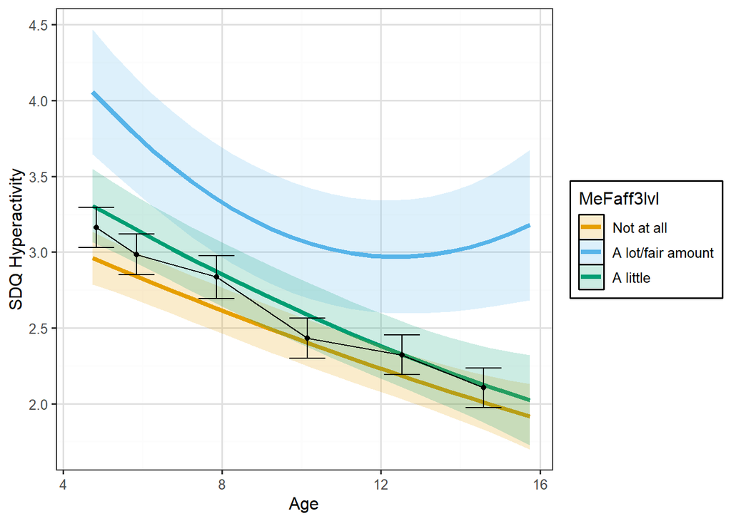

### Peer problems

[1] “No singular fit” [1] “No convergence issues”

| REML |
| --- |
| 20619 |

|  | Dsdpr1 |  |  |
| --- | --- | --- | --- |
| Predictors | Estimates | CI | p |
| (Intercept) | 0.89 | 0.79 – 0.99 | **<0.001** |
| age cent | 0.06 | 0.02 – 0.09 | **0.001** |
| MeFaff3lvl [A lot/fair amount] | 0.64 | 0.39 – 0.89 | **<0.001** |
| MeFaff3lvl [A little] | 0.08 | -0.08 – 0.25 | 0.331 |
| age cent^2 | -0.01 | -0.02 – 0.01 | 0.441 |
| age cent^3 | -0.00 | -0.00 – 0.00 | 0.530 |
| age cent^4 | 0.00 | -0.00 – 0.00 | 0.098 |
| age cent × MeFaff3lvl [A lot/fair amount] | 0.02 | -0.05 – 0.10 | 0.518 |
| age cent × MeFaff3lvl [A little] | 0.02 | -0.04 – 0.07 | 0.510 |
| MeFaff3lvl [A lot/fair amount] × age cent^2 | -0.02 | -0.05 – 0.01 | 0.295 |
| MeFaff3lvl [A little] × age cent^2 | 0.01 | -0.02 – 0.03 | 0.570 |
| MeFaff3lvl [A lot/fair amount] × age cent^3 | -0.00 | -0.01 – 0.00 | 0.390 |
| MeFaff3lvl [A little] × age cent^3 | -0.00 | -0.00 – 0.00 | 0.804 |
| MeFaff3lvl [A lot/fair amount] × age cent^4 | 0.00 | -0.00 – 0.00 | 0.143 |
| MeFaff3lvl [A little] × age cent^4 | -0.00 | -0.00 – 0.00 | 0.504 |
| Random Effects |  |  |  |
| σ<sup>2</sup> | 0.91 |  |  |
| τ<sub>00</sub> <sub>Idnumber</sub> | 0.86 |  |  |
| τ<sub>11</sub> <sub>Idnumber.age.cent</sub> | 0.02 |  |  |
| ρ<sub>01</sub> <sub>Idnumber</sub> | 0.44 |  |  |
| ICC | 0.54 |  |  |
| N <sub>Idnumber</sub> | 1045 |  |  |
| Observations | 6213 |  |  |
| Marginal R<sup>2</sup> / Conditional R<sup>2</sup> | 0.039 / 0.559 |  |  |

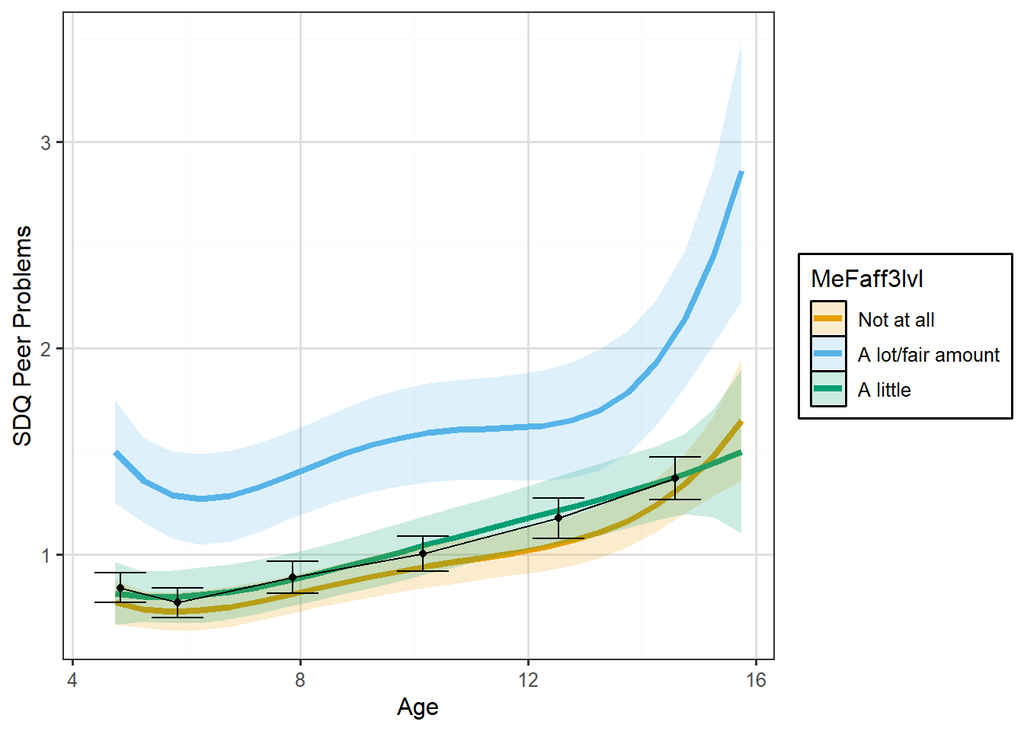